# Superstore Sales Analysis using SQL and Python

## Introduction

### Dataset Description

The Superstore dataset contains transactional sales records from a retail business. It includes information related to customer orders, products, sales, profit, discounts, shipping details, and geographical regions. The dataset consists of 9,994 records and provides valuable insights into business performance across different categories, customers, products, and regions.

The dataset was imported into a SQL database and analyzed using SQL queries and Python-based data visualization techniques to identify sales trends, profitability patterns, customer behavior, and product performance.

### Objectives

The primary objectives of this analysis are:

- Load and explore the Superstore dataset using SQL.
- Perform data quality validation checks.
- Analyze sales performance across regions, categories, and customer segments.
- Evaluate profitability trends and identify high-performing and loss-making products.
- Identify valuable customers and purchasing patterns.
- Generate business insights using SQL aggregations and filtering techniques.
- Visualize important trends and findings using Python charts.

### Tools Used

- **SQL Server** – Data storage and query execution.
- **SQLite** – SQL integration within Jupyter Notebook.
- **Python** – Data analysis and automation.
- **Pandas** – Data manipulation and query result handling.
- **Matplotlib** – Data visualization and chart creation.
- **Jupyter Notebook** – Interactive analysis and reporting environment.

# Database Setup

This section prepares the environment for SQL-based analysis within Jupyter Notebook. The dataset is loaded using Pandas, stored in an SQLite database, and verified before performing further analysis.

### Steps Performed

- Import required Python libraries.
- Load the Superstore dataset from a CSV file.
- Create an SQLite database connection.
- Load the dataset into an SQL table.
- Verify successful data loading.

```python
import pandas as pd
import sqlite3
import matplotlib.pyplot as plt
```

```python
df = pd.read_csv("Sample - Superstore.csv", encoding="latin1")
print("Dataset Loaded Successfully")
print("Rows:", df.shape[0])
print("Columns:", df.shape[1])
df.head()
```

```
Dataset Loaded Successfully
Rows: 9994
Columns: 21
```

|  | Row ID | Order ID | Order Date | Ship Date | Ship Mode | Customer ID | Customer Name | Segment | Country | City | ... | Postal Code | Region | Product ID | Category | Sub-Category | Product Name | Sales | Quantity | Discount | Profit |
| --- | --- | --- | --- | --- | --- | --- | --- | --- | --- | --- | --- | --- | --- | --- | --- | --- | --- | --- | --- | --- | --- |
| 0 | 1 | CA-2016-152156 | 11/8/2016 | 11/11/2016 | Second Class | CG-12520 | Claire Gute | Consumer | United States | Henderson | ... | 42420 | South | FUR-BO-10001798 | Furniture | Bookcases | Bush Somerset Collection Bookcase | 261.9600 | 2 | 0.00 | 41.9136 |
| 1 | 2 | CA-2016-152156 | 11/8/2016 | 11/11/2016 | Second Class | CG-12520 | Claire Gute | Consumer | United States | Henderson | ... | 42420 | South | FUR-CH-10000454 | Furniture | Chairs | Hon Deluxe Fabric Upholstered Stacking Chairs,... | 731.9400 | 3 | 0.00 | 219.5820 |
| 2 | 3 | CA-2016-138688 | 6/12/2016 | 6/16/2016 | Second Class | DV-13045 | Darrin Van Huff | Corporate | United States | Los Angeles | ... | 90036 | West | OFF-LA-10000240 | Office Supplies | Labels | Self-Adhesive Address Labels for Typewriters b... | 14.6200 | 2 | 0.00 | 6.8714 |
| 3 | 4 | US-2015-108966 | 10/11/2015 | 10/18/2015 | Standard Class | SO-20335 | Sean O'Donnell | Consumer | United States | Fort Lauderdale | ... | 33311 | South | FUR-TA-10000577 | Furniture | Tables | Bretford CR4500 Series Slim Rectangular Table | 957.5775 | 5 | 0.45 | -383.0310 |
| 4 | 5 | US-2015-108966 | 10/11/2015 | 10/18/2015 | Standard Class | SO-20335 | Sean O'Donnell | Consumer | United States | Fort Lauderdale | ... | 33311 | South | OFF-ST-10000760 | Office Supplies | Storage | Eldon Fold 'N Roll Cart System | 22.3680 | 2 | 0.20 | 2.5164 |

5 rows × 21 columns

```python
conn = sqlite3.connect("superstore.db")

print("SQLite Database Connected Successfully")
```

```
SQLite Database Connected Successfully
```

```python
df.to_sql(
    "Superstore_Data",
    conn,
    if_exists="replace",
    index=False
)

print("Table Created Successfully")
```

```
Table Created Successfully
```

```python
query = """
SELECT COUNT(*) AS TotalRows
FROM Superstore_Data
"""

pd.read_sql_query(query, conn)
```

|  | TotalRows |
| --- | --- |
| 0 | 9994 |

```python
query = """
SELECT *
FROM Superstore_Data
LIMIT 10
"""

pd.read_sql_query(query, conn)
```

|  | Row ID | Order ID | Order Date | Ship Date | Ship Mode | Customer ID | Customer Name | Segment | Country | City | ... | Postal Code | Region | Product ID | Category | Sub-Category | Product Name | Sales | Quantity | Discount | Profit |
| --- | --- | --- | --- | --- | --- | --- | --- | --- | --- | --- | --- | --- | --- | --- | --- | --- | --- | --- | --- | --- | --- |
| 0 | 1 | CA-2016-152156 | 11/8/2016 | 11/11/2016 | Second Class | CG-12520 | Claire Gute | Consumer | United States | Henderson | ... | 42420 | South | FUR-BO-10001798 | Furniture | Bookcases | Bush Somerset Collection Bookcase | 261.9600 | 2 | 0.00 | 41.9136 |
| 1 | 2 | CA-2016-152156 | 11/8/2016 | 11/11/2016 | Second Class | CG-12520 | Claire Gute | Consumer | United States | Henderson | ... | 42420 | South | FUR-CH-10000454 | Furniture | Chairs | Hon Deluxe Fabric Upholstered Stacking Chairs,... | 731.9400 | 3 | 0.00 | 219.5820 |
| 2 | 3 | CA-2016-138688 | 6/12/2016 | 6/16/2016 | Second Class | DV-13045 | Darrin Van Huff | Corporate | United States | Los Angeles | ... | 90036 | West | OFF-LA-10000240 | Office Supplies | Labels | Self-Adhesive Address Labels for Typewriters b... | 14.6200 | 2 | 0.00 | 6.8714 |
| 3 | 4 | US-2015-108966 | 10/11/2015 | 10/18/2015 | Standard Class | SO-20335 | Sean O'Donnell | Consumer | United States | Fort Lauderdale | ... | 33311 | South | FUR-TA-10000577 | Furniture | Tables | Bretford CR4500 Series Slim Rectangular Table | 957.5775 | 5 | 0.45 | -383.0310 |
| 4 | 5 | US-2015-108966 | 10/11/2015 | 10/18/2015 | Standard Class | SO-20335 | Sean O'Donnell | Consumer | United States | Fort Lauderdale | ... | 33311 | South | OFF-ST-10000760 | Office Supplies | Storage | Eldon Fold 'N Roll Cart System | 22.3680 | 2 | 0.20 | 2.5164 |
| 5 | 6 | CA-2014-115812 | 6/9/2014 | 6/14/2014 | Standard Class | BH-11710 | Brosina Hoffman | Consumer | United States | Los Angeles | ... | 90032 | West | FUR-FU-10001487 | Furniture | Furnishings | Eldon Expressions Wood and Plastic Desk Access... | 48.8600 | 7 | 0.00 | 14.1694 |
| 6 | 7 | CA-2014-115812 | 6/9/2014 | 6/14/2014 | Standard Class | BH-11710 | Brosina Hoffman | Consumer | United States | Los Angeles | ... | 90032 | West | OFF-AR-10002833 | Office Supplies | Art | Newell 322 | 7.2800 | 4 | 0.00 | 1.9656 |
| 7 | 8 | CA-2014-115812 | 6/9/2014 | 6/14/2014 | Standard Class | BH-11710 | Brosina Hoffman | Consumer | United States | Los Angeles | ... | 90032 | West | TEC-PH-10002275 | Technology | Phones | Mitel 5320 IP Phone VoIP phone | 907.1520 | 6 | 0.20 | 90.7152 |
| 8 | 9 | CA-2014-115812 | 6/9/2014 | 6/14/2014 | Standard Class | BH-11710 | Brosina Hoffman | Consumer | United States | Los Angeles | ... | 90032 | West | OFF-BI-10003910 | Office Supplies | Binders | DXL Angle-View Binders with Locking Rings by S... | 18.5040 | 3 | 0.20 | 5.7825 |
| 9 | 10 | CA-2014-115812 | 6/9/2014 | 6/14/2014 | Standard Class | BH-11710 | Brosina Hoffman | Consumer | United States | Los Angeles | ... | 90032 | West | OFF-AP-10002892 | Office Supplies | Appliances | Belkin F5C206VTEL 6 Outlet Surge | 114.9000 | 5 | 0.00 | 34.4700 |

10 rows × 21 columns

# Data Exploration

This section explores the structure and contents of the Superstore dataset before performing detailed business analysis.

The objectives of this section are:

- Examine sample records from the dataset.
- Determine the total number of records.
- Calculate the number of unique orders.
- Review the table schema and data types.
- Identify available regions and product categories.

Understanding the dataset structure is important for selecting appropriate analysis techniques and ensuring data consistency throughout the project.

```python
query = """
SELECT *
FROM Superstore_Data
LIMIT 10
"""

pd.read_sql_query(query, conn)
```

|  | Row ID | Order ID | Order Date | Ship Date | Ship Mode | Customer ID | Customer Name | Segment | Country | City | ... | Postal Code | Region | Product ID | Category | Sub-Category | Product Name | Sales | Quantity | Discount | Profit |
| --- | --- | --- | --- | --- | --- | --- | --- | --- | --- | --- | --- | --- | --- | --- | --- | --- | --- | --- | --- | --- | --- |
| 0 | 1 | CA-2016-152156 | 11/8/2016 | 11/11/2016 | Second Class | CG-12520 | Claire Gute | Consumer | United States | Henderson | ... | 42420 | South | FUR-BO-10001798 | Furniture | Bookcases | Bush Somerset Collection Bookcase | 261.9600 | 2 | 0.00 | 41.9136 |
| 1 | 2 | CA-2016-152156 | 11/8/2016 | 11/11/2016 | Second Class | CG-12520 | Claire Gute | Consumer | United States | Henderson | ... | 42420 | South | FUR-CH-10000454 | Furniture | Chairs | Hon Deluxe Fabric Upholstered Stacking Chairs,... | 731.9400 | 3 | 0.00 | 219.5820 |
| 2 | 3 | CA-2016-138688 | 6/12/2016 | 6/16/2016 | Second Class | DV-13045 | Darrin Van Huff | Corporate | United States | Los Angeles | ... | 90036 | West | OFF-LA-10000240 | Office Supplies | Labels | Self-Adhesive Address Labels for Typewriters b... | 14.6200 | 2 | 0.00 | 6.8714 |
| 3 | 4 | US-2015-108966 | 10/11/2015 | 10/18/2015 | Standard Class | SO-20335 | Sean O'Donnell | Consumer | United States | Fort Lauderdale | ... | 33311 | South | FUR-TA-10000577 | Furniture | Tables | Bretford CR4500 Series Slim Rectangular Table | 957.5775 | 5 | 0.45 | -383.0310 |
| 4 | 5 | US-2015-108966 | 10/11/2015 | 10/18/2015 | Standard Class | SO-20335 | Sean O'Donnell | Consumer | United States | Fort Lauderdale | ... | 33311 | South | OFF-ST-10000760 | Office Supplies | Storage | Eldon Fold 'N Roll Cart System | 22.3680 | 2 | 0.20 | 2.5164 |
| 5 | 6 | CA-2014-115812 | 6/9/2014 | 6/14/2014 | Standard Class | BH-11710 | Brosina Hoffman | Consumer | United States | Los Angeles | ... | 90032 | West | FUR-FU-10001487 | Furniture | Furnishings | Eldon Expressions Wood and Plastic Desk Access... | 48.8600 | 7 | 0.00 | 14.1694 |
| 6 | 7 | CA-2014-115812 | 6/9/2014 | 6/14/2014 | Standard Class | BH-11710 | Brosina Hoffman | Consumer | United States | Los Angeles | ... | 90032 | West | OFF-AR-10002833 | Office Supplies | Art | Newell 322 | 7.2800 | 4 | 0.00 | 1.9656 |
| 7 | 8 | CA-2014-115812 | 6/9/2014 | 6/14/2014 | Standard Class | BH-11710 | Brosina Hoffman | Consumer | United States | Los Angeles | ... | 90032 | West | TEC-PH-10002275 | Technology | Phones | Mitel 5320 IP Phone VoIP phone | 907.1520 | 6 | 0.20 | 90.7152 |
| 8 | 9 | CA-2014-115812 | 6/9/2014 | 6/14/2014 | Standard Class | BH-11710 | Brosina Hoffman | Consumer | United States | Los Angeles | ... | 90032 | West | OFF-BI-10003910 | Office Supplies | Binders | DXL Angle-View Binders with Locking Rings by S... | 18.5040 | 3 | 0.20 | 5.7825 |
| 9 | 10 | CA-2014-115812 | 6/9/2014 | 6/14/2014 | Standard Class | BH-11710 | Brosina Hoffman | Consumer | United States | Los Angeles | ... | 90032 | West | OFF-AP-10002892 | Office Supplies | Appliances | Belkin F5C206VTEL 6 Outlet Surge | 114.9000 | 5 | 0.00 | 34.4700 |

10 rows × 21 columns

```python
query = """
SELECT COUNT(*) AS TotalRows
FROM Superstore_Data
"""

pd.read_sql_query(query, conn)
```

|  | TotalRows |
| --- | --- |
| 0 | 9994 |

```python
query = """
SELECT COUNT(DISTINCT "Order ID") AS TotalOrders
FROM Superstore_Data
"""

pd.read_sql_query(query, conn)
```

|  | TotalOrders |
| --- | --- |
| 0 | 5009 |

```python
query = """
PRAGMA table_info(Superstore_Data);
"""

pd.read_sql_query(query, conn)
```

|  | cid | name | type | notnull | dflt_value | pk |
| --- | --- | --- | --- | --- | --- | --- |
| 0 | 0 | Row ID | INTEGER | 0 | None | 0 |
| 1 | 1 | Order ID | TEXT | 0 | None | 0 |
| 2 | 2 | Order Date | TEXT | 0 | None | 0 |
| 3 | 3 | Ship Date | TEXT | 0 | None | 0 |
| 4 | 4 | Ship Mode | TEXT | 0 | None | 0 |
| 5 | 5 | Customer ID | TEXT | 0 | None | 0 |
| 6 | 6 | Customer Name | TEXT | 0 | None | 0 |
| 7 | 7 | Segment | TEXT | 0 | None | 0 |
| 8 | 8 | Country | TEXT | 0 | None | 0 |
| 9 | 9 | City | TEXT | 0 | None | 0 |
| 10 | 10 | State | TEXT | 0 | None | 0 |
| 11 | 11 | Postal Code | INTEGER | 0 | None | 0 |
| 12 | 12 | Region | TEXT | 0 | None | 0 |
| 13 | 13 | Product ID | TEXT | 0 | None | 0 |
| 14 | 14 | Category | TEXT | 0 | None | 0 |
| 15 | 15 | Sub-Category | TEXT | 0 | None | 0 |
| 16 | 16 | Product Name | TEXT | 0 | None | 0 |
| 17 | 17 | Sales | REAL | 0 | None | 0 |
| 18 | 18 | Quantity | INTEGER | 0 | None | 0 |
| 19 | 19 | Discount | REAL | 0 | None | 0 |
| 20 | 20 | Profit | REAL | 0 | None | 0 |

```python
query = """
SELECT DISTINCT Region
FROM Superstore_Data
"""

pd.read_sql_query(query, conn)
```

|  | Region |
| --- | --- |
| 0 | South |
| 1 | West |
| 2 | Central |
| 3 | East |

```python
query = """
SELECT DISTINCT Category
FROM Superstore_Data
"""

pd.read_sql_query(query, conn)
```

|  | Category |
| --- | --- |
| 0 | Furniture |
| 1 | Office Supplies |
| 2 | Technology |

## Data Exploration Summary

- The dataset contains 9,994 transaction records and 5,009 unique orders.
- Customer, product, sales, profit, and geographical information are available for analysis.
- Operations span four regions: East, West, South, and Central.
- Products are organized into three major categories: Furniture, Office Supplies, and Technology.
- The dataset structure is suitable for sales, profitability, customer, and product analysis.

# Section 4 - Data Quality Checks

Data quality validation is an important step before performing business analysis. This section verifies the integrity and consistency of the dataset by checking for:

- Missing values in critical columns
- Duplicate records
- Invalid discount values
- Negative sales values
- Loss-making transactions
- Missing customer information

These checks help ensure the reliability of subsequent analyses and business insights.

```python
query = """
SELECT
    SUM(CASE WHEN "Row ID" IS NULL THEN 1 ELSE 0 END) AS Null_RowID,
    SUM(CASE WHEN "Order ID" IS NULL THEN 1 ELSE 0 END) AS Null_OrderID,
    SUM(CASE WHEN "Customer ID" IS NULL THEN 1 ELSE 0 END) AS Null_CustomerID,
    SUM(CASE WHEN Sales IS NULL THEN 1 ELSE 0 END) AS Null_Sales,
    SUM(CASE WHEN Profit IS NULL THEN 1 ELSE 0 END) AS Null_Profit
FROM Superstore_Data
"""

pd.read_sql_query(query, conn)
```

|  | Null_RowID | Null_OrderID | Null_CustomerID | Null_Sales | Null_Profit |
| --- | --- | --- | --- | --- | --- |
| 0 | 0 | 0 | 0 | 0 | 0 |

```python
query = """
SELECT
    "Row ID",
    COUNT(*) AS DuplicateCount
FROM Superstore_Data
GROUP BY "Row ID"
HAVING COUNT(*) > 1
"""

pd.read_sql_query(query, conn)
```

|  | Row ID | DuplicateCount |
| --- | --- | --- |

```python
query = """
SELECT *
FROM Superstore_Data
WHERE Discount < 0
   OR Discount > 1
"""

pd.read_sql_query(query, conn)
```

|  | Row ID | Order ID | Order Date | Ship Date | Ship Mode | Customer ID | Customer Name | Segment | Country | City | ... | Postal Code | Region | Product ID | Category | Sub-Category | Product Name | Sales | Quantity | Discount | Profit |
| --- | --- | --- | --- | --- | --- | --- | --- | --- | --- | --- | --- | --- | --- | --- | --- | --- | --- | --- | --- | --- | --- |

0 rows × 21 columns

```python
query = """
SELECT *
FROM Superstore_Data
WHERE Sales < 0
"""

pd.read_sql_query(query, conn)
```

|  | Row ID | Order ID | Order Date | Ship Date | Ship Mode | Customer ID | Customer Name | Segment | Country | City | ... | Postal Code | Region | Product ID | Category | Sub-Category | Product Name | Sales | Quantity | Discount | Profit |
| --- | --- | --- | --- | --- | --- | --- | --- | --- | --- | --- | --- | --- | --- | --- | --- | --- | --- | --- | --- | --- | --- |

0 rows × 21 columns

```python
query = """
SELECT
    COUNT(*) AS NegativeProfitRecords
FROM Superstore_Data
WHERE Profit < 0
"""

pd.read_sql_query(query, conn)
```

|  | NegativeProfitRecords |
| --- | --- |
| 0 | 1871 |

```python
query = """
SELECT
    COUNT(*) AS MissingCustomerNames
FROM Superstore_Data
WHERE "Customer Name" IS NULL
"""

pd.read_sql_query(query, conn)
```

|  | MissingCustomerNames |
| --- | --- |
| 0 | 0 |

## Data Quality Summary

- No missing values were found in critical columns.
- No duplicate transaction records were detected.
- All discount values fall within the expected business range.
- No negative sales values exist in the dataset.
- 1,871 transactions generated negative profit, representing genuine business losses.
- Customer information is complete and available for analysis.

Overall, the dataset demonstrates strong data quality and is suitable for business intelligence and analytical reporting.

# Section 5 - Sales Analysis

This section analyzes sales performance across different business dimensions including regions, product categories, customer segments, products, states, and time periods.

The analysis uses SQL aggregation functions such as SUM(), GROUP BY, ORDER BY, and LIMIT to identify sales trends and high-performing business areas.

Key objectives:

- Calculate total sales generated by the business.
- Compare sales across regions.
- Analyze category and segment performance.
- Identify top-selling products.
- Evaluate state-wise sales performance.
- Study yearly and monthly sales trends.
- Determine the highest-value customer orders.

```python
query = """
SELECT
    ROUND(SUM(Sales),2) AS TotalSales
FROM Superstore_Data
"""

pd.read_sql_query(query, conn)
```

|  | TotalSales |
| --- | --- |
| 0 | 2297200.86 |

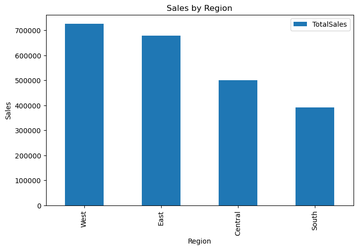

```python
query = """
SELECT
    Region,
    ROUND(SUM(Sales),2) AS TotalSales
FROM Superstore_Data
GROUP BY Region
ORDER BY TotalSales DESC
"""

sales_region = pd.read_sql_query(query, conn)

sales_region
sales_region.plot(
    x="Region",
    y="TotalSales",
    kind="bar",
    figsize=(8,5)
)

plt.title("Sales by Region")
plt.ylabel("Sales")
plt.show()
```

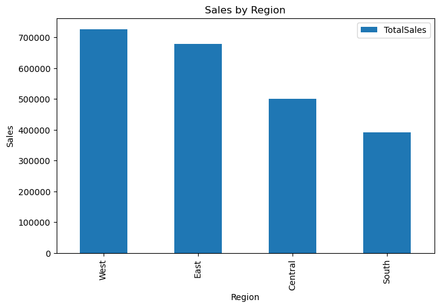

```python
sales_region.plot(
    x="Region",
    y="TotalSales",
    kind="bar",
    figsize=(8,5)
)

plt.title("Sales by Region")
plt.ylabel("Sales")
plt.show()
```

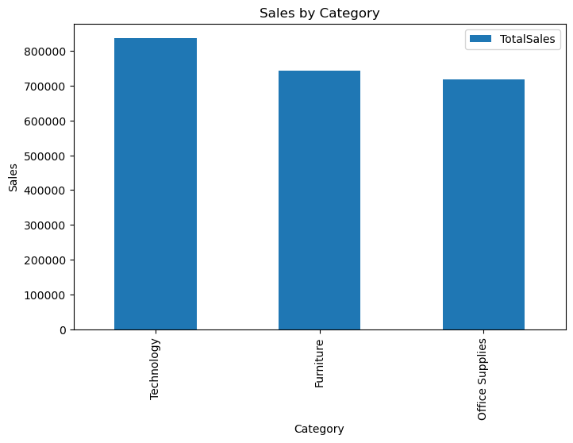

```python
query = """
SELECT
    Category,
    ROUND(SUM(Sales),2) AS TotalSales
FROM Superstore_Data
GROUP BY Category
ORDER BY TotalSales DESC
"""

sales_category = pd.read_sql_query(query, conn)

sales_category
sales_category.plot(
    x="Category",
    y="TotalSales",
    kind="bar",
    figsize=(8,5)
)

plt.title("Sales by Category")
plt.ylabel("Sales")
plt.show()
```

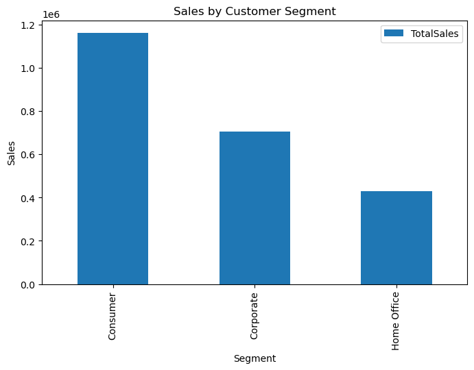

```python
query = """
SELECT
    Segment,
    ROUND(SUM(Sales),2) AS TotalSales
FROM Superstore_Data
GROUP BY Segment
ORDER BY TotalSales DESC
"""

sales_segment = pd.read_sql_query(query, conn)

sales_segment
sales_segment.plot(
    x="Segment",
    y="TotalSales",
    kind="bar",
    figsize=(8,5)
)

plt.title("Sales by Customer Segment")
plt.ylabel("Sales")
plt.show()
```

```python
query = """
SELECT
    "Product Name",
    ROUND(SUM(Sales),2) AS TotalSales
FROM Superstore_Data
GROUP BY "Product Name"
ORDER BY TotalSales DESC
LIMIT 10
"""

top_products = pd.read_sql_query(query, conn)

top_products
```

|  | Product Name | TotalSales |
| --- | --- | --- |
| 0 | Canon imageCLASS 2200 Advanced Copier | 61599.82 |
| 1 | Fellowes PB500 Electric Punch Plastic Comb Bin... | 27453.38 |
| 2 | Cisco TelePresence System EX90 Videoconferenci... | 22638.48 |
| 3 | HON 5400 Series Task Chairs for Big and Tall | 21870.58 |
| 4 | GBC DocuBind TL300 Electric Binding System | 19823.48 |
| 5 | GBC Ibimaster 500 Manual ProClick Binding System | 19024.50 |
| 6 | Hewlett Packard LaserJet 3310 Copier | 18839.69 |
| 7 | HP Designjet T520 Inkjet Large Format Printer ... | 18374.90 |
| 8 | GBC DocuBind P400 Electric Binding System | 17965.07 |
| 9 | High Speed Automatic Electric Letter Opener | 17030.31 |

```python
query = """
SELECT
    State,
    ROUND(SUM(Sales),2) AS TotalSales
FROM Superstore_Data
GROUP BY State
ORDER BY TotalSales DESC
LIMIT 10
"""

top_states = pd.read_sql_query(query, conn)

top_states
```

|  | State | TotalSales |
| --- | --- | --- |
| 0 | California | 457687.63 |
| 1 | New York | 310876.27 |
| 2 | Texas | 170188.05 |
| 3 | Washington | 138641.27 |
| 4 | Pennsylvania | 116511.91 |
| 5 | Florida | 89473.71 |
| 6 | Illinois | 80166.10 |
| 7 | Ohio | 78258.14 |
| 8 | Michigan | 76269.61 |
| 9 | Virginia | 70636.72 |

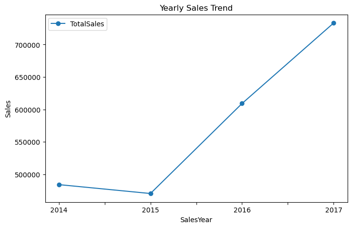

```python
query = """
SELECT
    substr("Order Date",-4) AS SalesYear,
    ROUND(SUM(Sales),2) AS TotalSales
FROM Superstore_Data
GROUP BY SalesYear
ORDER BY SalesYear
"""

sales_year = pd.read_sql_query(query, conn)

sales_year
sales_year.plot(
    x="SalesYear",
    y="TotalSales",
    kind="line",
    marker="o",
    figsize=(8,5)
)

plt.title("Yearly Sales Trend")
plt.ylabel("Sales")
plt.show()
```

```python
query = """
SELECT
    substr("Order Date",1,instr("Order Date","/")-1) AS SalesMonth,
    ROUND(SUM(Sales),2) AS TotalSales
FROM Superstore_Data
GROUP BY SalesMonth
ORDER BY CAST(SalesMonth AS INTEGER)
"""

sales_month = pd.read_sql_query(query, conn)

sales_month
```

|  | SalesMonth | TotalSales |
| --- | --- | --- |
| 0 | 1 | 94924.84 |
| 1 | 2 | 59751.25 |
| 2 | 3 | 205005.49 |
| 3 | 4 | 137762.13 |
| 4 | 5 | 155028.81 |
| 5 | 6 | 152718.68 |
| 6 | 7 | 147238.10 |
| 7 | 8 | 159044.06 |
| 8 | 9 | 307649.95 |
| 9 | 10 | 200322.98 |
| 10 | 11 | 352461.07 |
| 11 | 12 | 325293.50 |

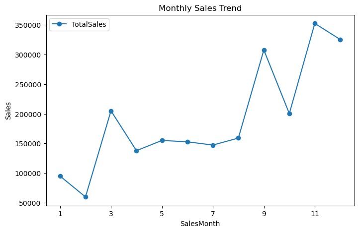

```python
sales_month.plot(
    x="SalesMonth",
    y="TotalSales",
    kind="line",
    marker="o",
    figsize=(8,5)
)

plt.title("Monthly Sales Trend")
plt.ylabel("Sales")
plt.show()
```

```python
query = """
SELECT
    "Order ID",
    ROUND(SUM(Sales),2) AS TotalSales
FROM Superstore_Data
GROUP BY "Order ID"
ORDER BY TotalSales DESC
LIMIT 10
"""

pd.read_sql_query(query, conn)
```

|  | Order ID | TotalSales |
| --- | --- | --- |
| 0 | CA-2014-145317 | 23661.23 |
| 1 | CA-2016-118689 | 18336.74 |
| 2 | CA-2017-140151 | 14052.48 |
| 3 | CA-2017-127180 | 13716.46 |
| 4 | CA-2014-139892 | 10539.90 |
| 5 | CA-2017-166709 | 10499.97 |
| 6 | CA-2014-116904 | 9900.19 |
| 7 | CA-2016-117121 | 9892.74 |
| 8 | US-2016-107440 | 9135.19 |
| 9 | CA-2016-158841 | 8805.04 |

# Section 6 - Profit Analysis

Profitability is a key indicator of business performance. While sales measure revenue generation, profit determines whether products, customers, and regions contribute positively to the business.

This section analyzes:

- Overall business profit
- Profit by region
- Profit by category
- Most profitable products
- Least profitable products

The goal is to identify areas driving profitability and areas causing financial losses.

```python
query = """
SELECT
    ROUND(SUM(Profit),2) AS TotalProfit
FROM Superstore_Data
"""

pd.read_sql_query(query, conn)
```

|  | TotalProfit |
| --- | --- |
| 0 | 286397.02 |

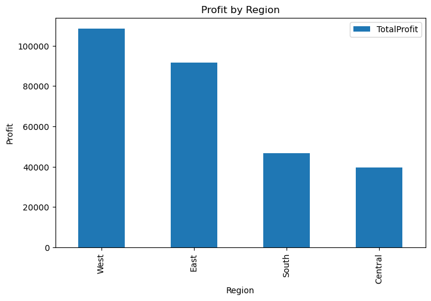

```python
query = """
SELECT
    Region,
    ROUND(SUM(Profit),2) AS TotalProfit
FROM Superstore_Data
GROUP BY Region
ORDER BY TotalProfit DESC
"""

profit_region = pd.read_sql_query(query, conn)

profit_region
profit_region.plot(
    x="Region",
    y="TotalProfit",
    kind="bar",
    figsize=(8,5)
)

plt.title("Profit by Region")
plt.ylabel("Profit")
plt.show()
```

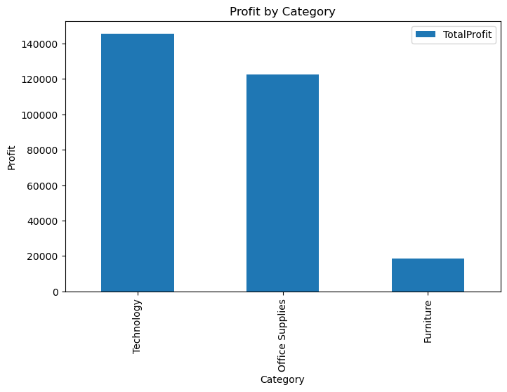

```python
query = """
SELECT
    Category,
    ROUND(SUM(Profit),2) AS TotalProfit
FROM Superstore_Data
GROUP BY Category
ORDER BY TotalProfit DESC
"""

profit_category = pd.read_sql_query(query, conn)

profit_category
profit_category.plot(
    x="Category",
    y="TotalProfit",
    kind="bar",
    figsize=(8,5)
)

plt.title("Profit by Category")
plt.ylabel("Profit")
plt.show()
```

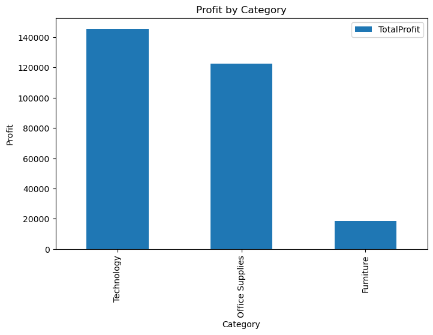

```python
query = """
SELECT
    Category,
    ROUND(SUM(Profit),2) AS TotalProfit
FROM Superstore_Data
GROUP BY Category
ORDER BY TotalProfit DESC
"""

profit_category = pd.read_sql_query(query, conn)

profit_category
profit_category.plot(
    x="Category",
    y="TotalProfit",
    kind="bar",
    figsize=(8,5)
)

plt.title("Profit by Category")
plt.ylabel("Profit")
plt.show()
```

```python
query = """
SELECT
    "Product Name",
    ROUND(SUM(Profit),2) AS TotalProfit
FROM Superstore_Data
GROUP BY "Product Name"
ORDER BY TotalProfit DESC
LIMIT 10
"""

top_profit_products = pd.read_sql_query(query, conn)

top_profit_products
```

|  | Product Name | TotalProfit |
| --- | --- | --- |
| 0 | Canon imageCLASS 2200 Advanced Copier | 25199.93 |
| 1 | Fellowes PB500 Electric Punch Plastic Comb Bin... | 7753.04 |
| 2 | Hewlett Packard LaserJet 3310 Copier | 6983.88 |
| 3 | Canon PC1060 Personal Laser Copier | 4570.93 |
| 4 | HP Designjet T520 Inkjet Large Format Printer ... | 4094.98 |
| 5 | Ativa V4110MDD Micro-Cut Shredder | 3772.95 |
| 6 | 3D Systems Cube Printer, 2nd Generation, Magenta | 3717.97 |
| 7 | Plantronics Savi W720 Multi-Device Wireless He... | 3696.28 |
| 8 | Ibico EPK-21 Electric Binding System | 3345.28 |
| 9 | Zebra ZM400 Thermal Label Printer | 3343.54 |

```python
query = """
SELECT
    "Product Name",
    ROUND(SUM(Profit),2) AS TotalProfit
FROM Superstore_Data
GROUP BY "Product Name"
ORDER BY TotalProfit ASC
LIMIT 10
"""

loss_products = pd.read_sql_query(query, conn)

loss_products
```

|  | Product Name | TotalProfit |
| --- | --- | --- |
| 0 | Cubify CubeX 3D Printer Double Head Print | -8879.97 |
| 1 | Lexmark MX611dhe Monochrome Laser Printer | -4589.97 |
| 2 | Cubify CubeX 3D Printer Triple Head Print | -3839.99 |
| 3 | Chromcraft Bull-Nose Wood Oval Conference Tabl... | -2876.12 |
| 4 | Bush Advantage Collection Racetrack Conference... | -1934.40 |
| 5 | GBC DocuBind P400 Electric Binding System | -1878.17 |
| 6 | Cisco TelePresence System EX90 Videoconferenci... | -1811.08 |
| 7 | Martin Yale Chadless Opener Electric Letter Op... | -1299.18 |
| 8 | Balt Solid Wood Round Tables | -1201.06 |
| 9 | BoxOffice By Design Rectangular and Half-Moon ... | -1148.44 |

## Profit Analysis Summary

- The business generated approximately $286,397 in total profit.
- The West region achieved the highest profitability.
- Technology was the most profitable product category.
- Furniture generated comparatively lower profits.
- A small group of products contributed significantly to overall profit.
- Several products consistently generated losses and may require strategic attention.

Overall, profitability is concentrated within specific regions, categories, and products, highlighting opportunities for optimization.

# Section 7 - Customer Analysis

Customers are the primary drivers of business revenue and profitability. Understanding customer behavior helps identify high-value customers and evaluate the performance of different customer segments.

This section analyzes:

- Customers generating the highest sales
- Customers generating the highest profit
- Customer distribution across segments
- Average sales per customer segment

The objective is to identify valuable customers and understand purchasing patterns across market segments.

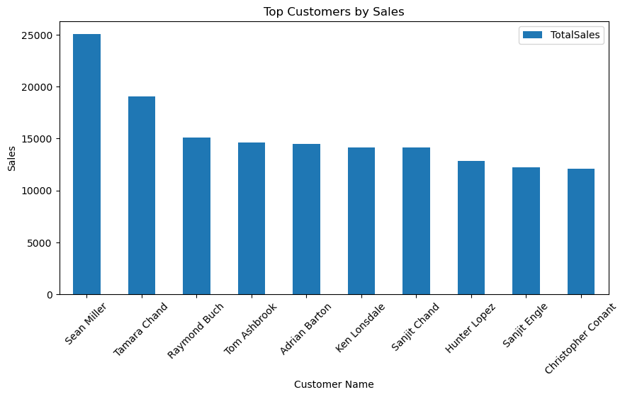

```python
query = """
SELECT
    "Customer Name",
    ROUND(SUM(Sales),2) AS TotalSales
FROM Superstore_Data
GROUP BY "Customer Name"
ORDER BY TotalSales DESC
LIMIT 10
"""

top_customers_sales = pd.read_sql_query(query, conn)

top_customers_sales
top_customers_sales.plot(
    x="Customer Name",
    y="TotalSales",
    kind="bar",
    figsize=(10,5)
)

plt.title("Top Customers by Sales")
plt.ylabel("Sales")
plt.xticks(rotation=45)
plt.show()
```

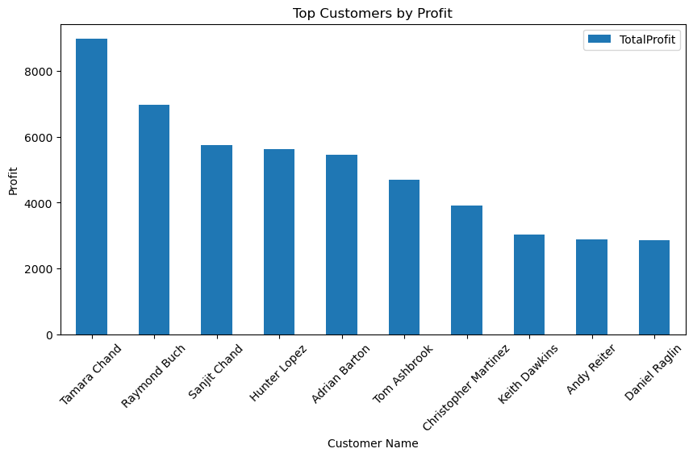

```python
query = """
SELECT
    "Customer Name",
    ROUND(SUM(Profit),2) AS TotalProfit
FROM Superstore_Data
GROUP BY "Customer Name"
ORDER BY TotalProfit DESC
LIMIT 10
"""

top_customers_profit = pd.read_sql_query(query, conn)

top_customers_profit
top_customers_profit.plot(
    x="Customer Name",
    y="TotalProfit",
    kind="bar",
    figsize=(10,5)
)

plt.title("Top Customers by Profit")
plt.ylabel("Profit")
plt.xticks(rotation=45)
plt.show()
```

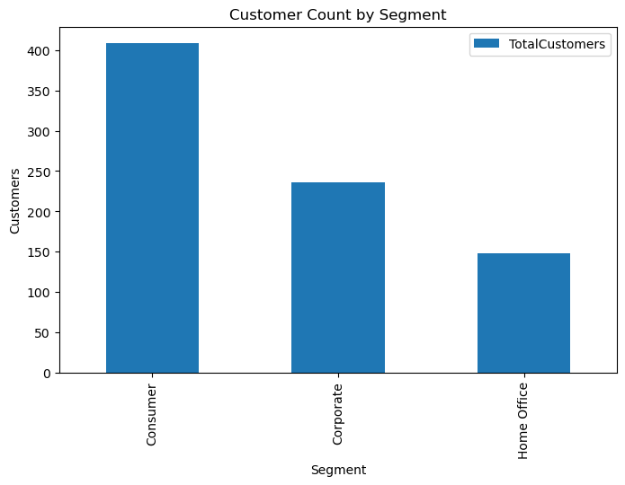

```python
query = """
SELECT
    Segment,
    COUNT(DISTINCT "Customer ID") AS TotalCustomers
FROM Superstore_Data
GROUP BY Segment
ORDER BY TotalCustomers DESC
"""

customer_segments = pd.read_sql_query(query, conn)

customer_segments
customer_segments.plot(
    x="Segment",
    y="TotalCustomers",
    kind="bar",
    figsize=(8,5)
)

plt.title("Customer Count by Segment")
plt.ylabel("Customers")
plt.show()
```

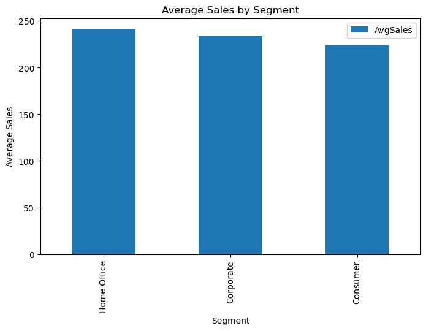

```python
query = """
SELECT
    Segment,
    ROUND(AVG(Sales),2) AS AvgSales
FROM Superstore_Data
GROUP BY Segment
ORDER BY AvgSales DESC
"""

avg_segment_sales = pd.read_sql_query(query, conn)

avg_segment_sales
avg_segment_sales.plot(
    x="Segment",
    y="AvgSales",
    kind="bar",
    figsize=(8,5)
)

plt.title("Average Sales by Segment")
plt.ylabel("Average Sales")
plt.show()
```

## Customer Analysis Summary

- Several customers contribute significantly to overall business sales.
- High-profit customers represent important long-term business value.
- The Consumer segment contains the largest customer base.
- Average sales vary across customer segments, indicating differences in purchasing patterns.
- Customer segmentation provides useful insights for marketing and retention strategies.

Understanding customer behavior helps the business focus on high-value customers and improve long-term profitability.

# Section 8 - Product Analysis

Products are the core drivers of revenue and profitability. Analyzing product performance helps identify best-selling products, profitable products, loss-making products, and high-performing product groups.

This section analyzes:

- Top products by sales
- Top products by profit
- Loss-making products
- Sales by sub-category
- Profit by sub-category

The objective is to evaluate product performance and identify opportunities for improvement.

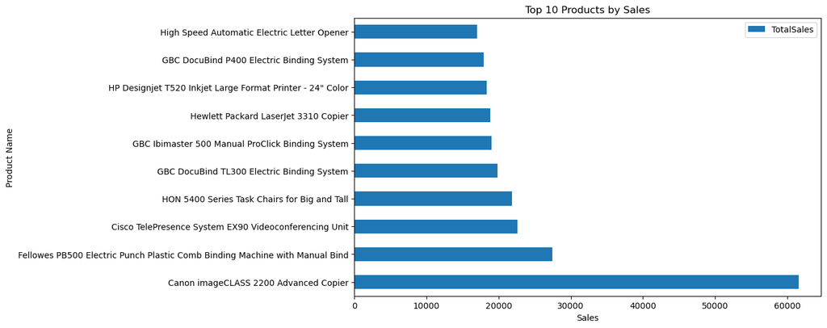

```python
query = """
SELECT
    "Product Name",
    ROUND(SUM(Sales),2) AS TotalSales
FROM Superstore_Data
GROUP BY "Product Name"
ORDER BY TotalSales DESC
LIMIT 10
"""

top_products_sales = pd.read_sql_query(query, conn)

top_products_sales
top_products_sales.plot(
    x="Product Name",
    y="TotalSales",
    kind="barh",
    figsize=(10,6)
)

plt.title("Top 10 Products by Sales")
plt.xlabel("Sales")
plt.show()
```

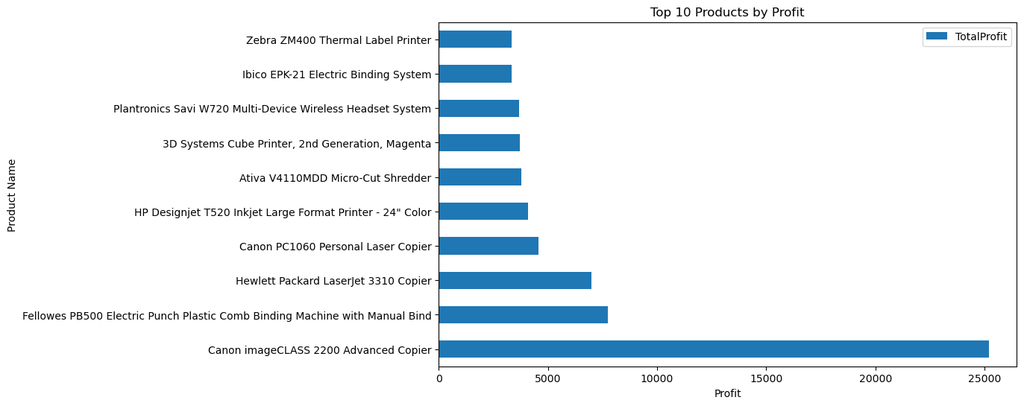

```python
query = """
SELECT
    "Product Name",
    ROUND(SUM(Profit),2) AS TotalProfit
FROM Superstore_Data
GROUP BY "Product Name"
ORDER BY TotalProfit DESC
LIMIT 10
"""

top_products_profit = pd.read_sql_query(query, conn)

top_products_profit
top_products_profit.plot(
    x="Product Name",
    y="TotalProfit",
    kind="barh",
    figsize=(10,6)
)

plt.title("Top 10 Products by Profit")
plt.xlabel("Profit")
plt.show()
```

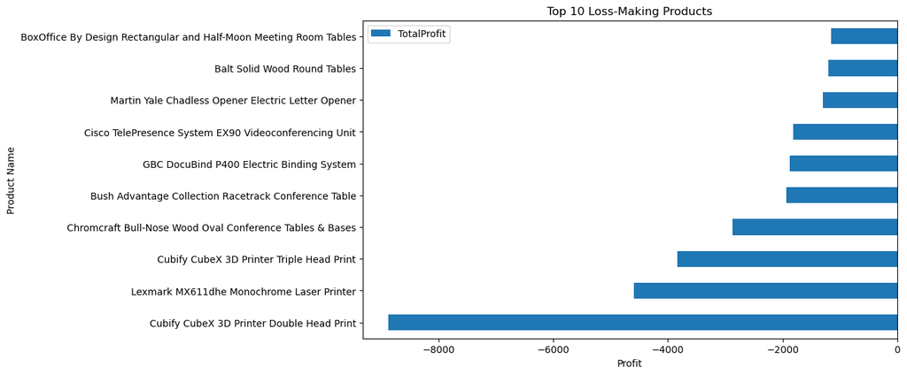

```python
query = """
SELECT
    "Product Name",
    ROUND(SUM(Profit),2) AS TotalProfit
FROM Superstore_Data
GROUP BY "Product Name"
ORDER BY TotalProfit ASC
LIMIT 10
"""

loss_products = pd.read_sql_query(query, conn)

loss_products
loss_products.plot(
    x="Product Name",
    y="TotalProfit",
    kind="barh",
    figsize=(10,6)
)

plt.title("Top 10 Loss-Making Products")
plt.xlabel("Profit")
plt.show()
```

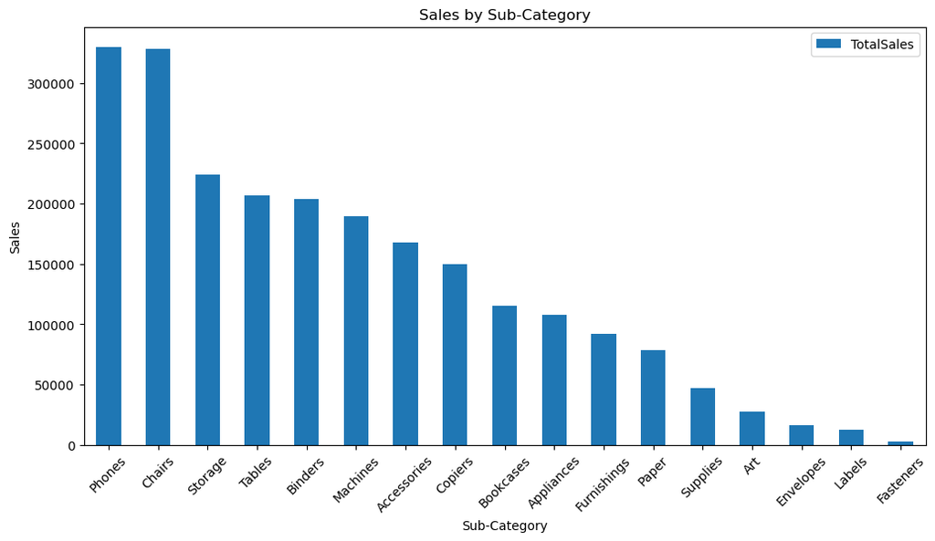

```python
query = """
SELECT
    "Sub-Category",
    ROUND(SUM(Sales),2) AS TotalSales
FROM Superstore_Data
GROUP BY "Sub-Category"
ORDER BY TotalSales DESC
"""

subcategory_sales = pd.read_sql_query(query, conn)

subcategory_sales
subcategory_sales.plot(
    x="Sub-Category",
    y="TotalSales",
    kind="bar",
    figsize=(12,6)
)

plt.title("Sales by Sub-Category")
plt.ylabel("Sales")
plt.xticks(rotation=45)
plt.show()
```

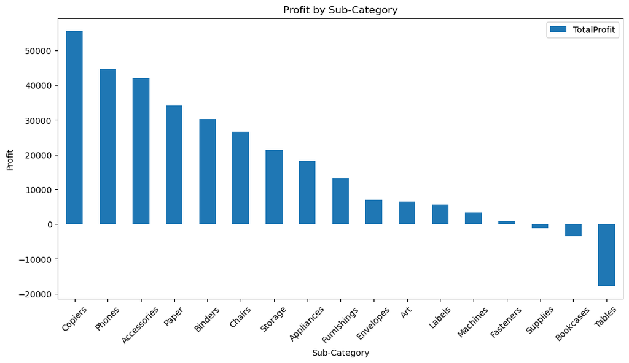

```python
query = """
SELECT
    "Sub-Category",
    ROUND(SUM(Profit),2) AS TotalProfit
FROM Superstore_Data
GROUP BY "Sub-Category"
ORDER BY TotalProfit DESC
"""

subcategory_profit = pd.read_sql_query(query, conn)

subcategory_profit
subcategory_profit.plot(
    x="Sub-Category",
    y="TotalProfit",
    kind="bar",
    figsize=(12,6)
)

plt.title("Profit by Sub-Category")
plt.ylabel("Profit")
plt.xticks(rotation=45)
plt.show()
```

## Product Analysis Summary

- A small group of products generates a large share of total sales.
- Canon imageCLASS 2200 Advanced Copier was among the most profitable products.
- Several products consistently generated losses despite producing sales revenue.
- Product performance differs significantly across sub-categories.
- Some sub-categories contribute strongly to profit while others require business attention.

Product-level analysis helps identify growth opportunities and improve inventory, pricing, and discount strategies.

# Section 9 - Business Insights

After analyzing sales, profit, customers, and products, this section combines key business metrics to identify trends, opportunities, and strategic insights.

The objective is to summarize business performance and support data-driven decision making.

Areas analyzed:

- Regional performance
- Yearly business growth
- High-value customers
- Category performance

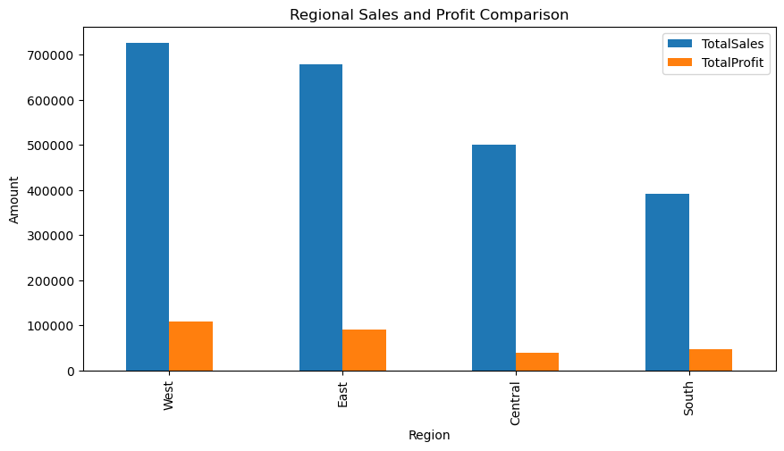

```python
query = """
SELECT
    Region,
    ROUND(SUM(Sales),2) AS TotalSales,
    ROUND(SUM(Profit),2) AS TotalProfit
FROM Superstore_Data
GROUP BY Region
ORDER BY TotalSales DESC
"""

regional_performance = pd.read_sql_query(query, conn)

regional_performance
regional_performance.set_index("Region")[["TotalSales","TotalProfit"]].plot(
    kind="bar",
    figsize=(10,5)
)

plt.title("Regional Sales and Profit Comparison")
plt.ylabel("Amount")
plt.show()
```

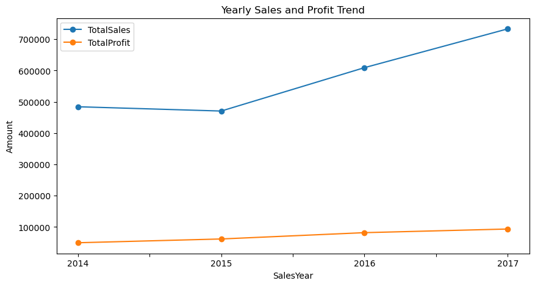

```python
query = """
SELECT
    substr("Order Date",-4) AS SalesYear,
    ROUND(SUM(Sales),2) AS TotalSales,
    ROUND(SUM(Profit),2) AS TotalProfit
FROM Superstore_Data
GROUP BY SalesYear
ORDER BY SalesYear
"""

yearly_growth = pd.read_sql_query(query, conn)

yearly_growth
yearly_growth.set_index("SalesYear")[["TotalSales","TotalProfit"]].plot(
    figsize=(10,5),
    marker="o"
)

plt.title("Yearly Sales and Profit Trend")
plt.ylabel("Amount")
plt.show()
```

```python
query = """
SELECT
    "Customer Name",
    ROUND(SUM(Profit),2) AS TotalProfit
FROM Superstore_Data
GROUP BY "Customer Name"
ORDER BY TotalProfit DESC
LIMIT 10
"""

top_profit_customers = pd.read_sql_query(query, conn)

top_profit_customers
```

|  | Customer Name | TotalProfit |
| --- | --- | --- |
| 0 | Tamara Chand | 8981.32 |
| 1 | Raymond Buch | 6976.10 |
| 2 | Sanjit Chand | 5757.41 |
| 3 | Hunter Lopez | 5622.43 |
| 4 | Adrian Barton | 5444.81 |
| 5 | Tom Ashbrook | 4703.79 |
| 6 | Christopher Martinez | 3899.89 |
| 7 | Keith Dawkins | 3038.63 |
| 8 | Andy Reiter | 2884.62 |
| 9 | Daniel Raglin | 2869.08 |

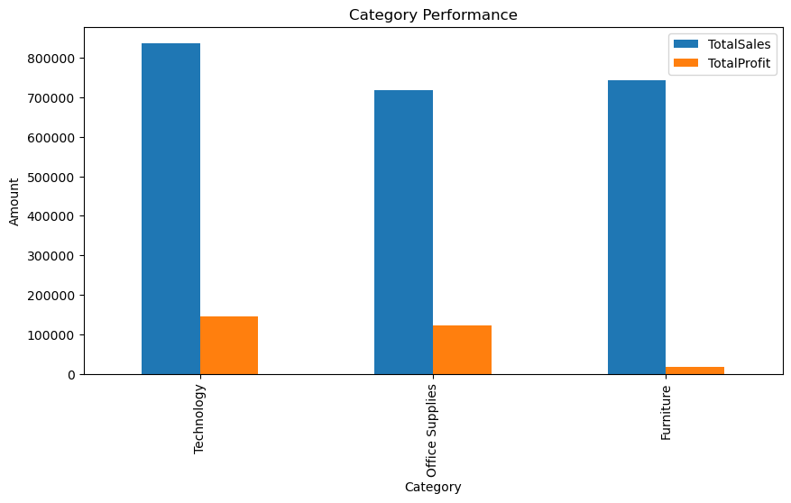

```python
query = """
SELECT
    Category,
    ROUND(SUM(Sales),2) AS TotalSales,
    ROUND(SUM(Profit),2) AS TotalProfit
FROM Superstore_Data
GROUP BY Category
ORDER BY TotalProfit DESC
"""

category_performance = pd.read_sql_query(query, conn)

category_performance
category_performance.set_index("Category")[["TotalSales","TotalProfit"]].plot(
    kind="bar",
    figsize=(10,5)
)

plt.title("Category Performance")
plt.ylabel("Amount")
plt.show()
```

## Business Insights Summary

### Regional Insights

- West region generated the highest sales and profit.
- East region ranked second in overall performance.

### Customer Insights

- A small group of high-value customers contributes significantly to overall profitability.
- Customer retention should remain a strategic priority.

### Product and Category Insights

- Technology is the most profitable category.
- Several products contribute substantial profits, while a few products consistently generate losses.
- Furniture generates strong sales but comparatively lower profitability.

### Strategic Recommendations

- Expand focus on high-performing regions and product categories.
- Strengthen relationships with high-value customers.
- Review pricing and discount strategies for loss-making products.
- Continue monitoring yearly growth trends to support future business planning.

# Final Conclusion

The Superstore dataset was successfully analyzed using SQL and Python to evaluate sales performance, profitability, customer behavior, product performance, and overall business trends.

The analysis began with data exploration and quality validation to ensure the reliability of the dataset. No significant data quality issues were identified, making the dataset suitable for business analysis and reporting.

Overall, the analysis demonstrates how SQL can be used to transform raw transactional data into meaningful business insights. Combining SQL with Python-based visualization techniques provides a powerful approach for data exploration, business intelligence, and decision-making.

This project successfully achieved all stated objectives and provided valuable insights into the operational and financial performance of the business.